# Ejemplos de práctica extraídos del apunte teórico de la unidad IV

### Las tablas a utilizar para realizar los ejercicios son las siguientes:

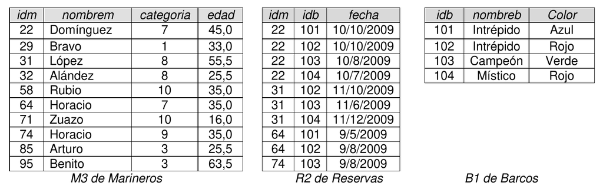

1. Averiguar el nombre de los marineros que han reservado el barco 103.

   Opción 1:

   ```
    π nombrem (σ idb == 103 (r2 ⋈ m3))
   ```

   Opción 2:

   ```
    π nombrem (σ idb == 103 (r2) ⋈ m3)
   ```

   *La opción 2 al hacer la selección primero, es menos costosa de calcular.*
2. Averiguar el nombre de los marineros que han reservado barcos rojos.

   ```
    π nombrem (m3 ⋈ (σ color == 'Rojo' (b1) ⋈ r2))
   ```

3. Averiguar el color de los barcos reservados por López.

   ```
    π color (b1 ⋈ r2 ⋈ σ nombrem == 'López' (m3))
   ```

4. Averiguar el nombre de los marineros que han reservado, como mínimo, un barco.

   ```
    π nombrem (m3 ⋈ r2)
   ```

5. Averiguar el nombre de los marineros que han reservado barcos rojos o verdes.

   Opción 1:

   ```
    π nombrem (σ color == 'Rojo' or color == 'Verde' (b1) ⋈ (m3 ⋈ r2))
   ```

   Opción 2:

   ```
    aux = σ color == 'Verde' (b1) ∪ σ color == 'Rojo' (b1)
   ```

   π nombrem (aux ⋈ r2 ⋈ m3)

   Opción 3:

   ```
    rojo_temp = π idm (σ color == 'Rojo' (b1) ⋈ r2)

    verde_temp = π idm (σ color == 'Verde' (b1) ⋈ r2)

    π nombrem ((rojo_temp ∪ verde_temp) ⋈ m3)
   ```

   *Yo prefiero la primer opción, aunque la tercera es fácilmente “convertible” a cuando te piden barcos rojos y verdes al mismo tiempo.*
6. Averiguar el nombre de los marineros que han reservado barcos rojos y verdes.

   ```
    rojo_temp = π idm (σ color == 'Rojo' (b1) ⋈ r2)

    verde_temp = π idm (σ color == 'Verde' (b1) ⋈ r2)

    π nombrem ((rojo_temp ∩ verde_temp) ⋈ m3)
   ```

7. Averiguar el nombre de los marineros que han reservado, como mínimo, dos barcos.

   ```
    reservas_1 = ρ idm ➡ idm1, nombrem ➡ nom1, idb ➡ idb1 (π idm, nombrem, idb (r2 ⋈ m3))

    reservas_2 = ρ idm1 ➡ idm2, nom1 ➡ nom2, idb1 ➡ idb2 (reservas_1)

    π nom1 (σ idm1 == idm2 and idb1 != idb2 (reservas_1 * reservas_2))
   ```

8. Averiguar el idm de los marineros con edad superior a 20 que no hayan reservado ningún barco rojo.

   ```
    π idm (σ edad > 20 (m3)) - π idm (σ color == 'Rojo' (b1) ⋈ r2 ⋈ m3)
   ```

9. Averiguar el nombre de los marineros que han reservado todos los barcos.

   ```
    π nombrem (m3 ⋈ π idm, idb (r2) ÷ π idb (b1))
   ```

   *El empleo de la palabra todos (o cada) es una buena indicación de que se podría aplicar la operación división.*
10. Averiguar el nombre de los marineros que han reservado todos los barcos llamados “Intrépido”.

    ```
    π nombrem (m3 ⋈ π idm, idb (r2) ÷ π idb (σ nombreb == 'Intrépido' (b1)))
    ```